# Geography of Water Resources

Andrew Murray

11/14/2018

## Geography of Water

Water is something a lot of us don’t think a lot about. Generally, we all go to turn on the tap and we can pour a glass of water and drink it without question or fear, but what does it take for that water to get to the tap? What happens when there is no water? There are almost an infinite number of ways in which your acces to water can be affected. Here in North Carolina, our access to water is most likely to be affected by contamination or problems with infrastructure. Generally we do not suffer from a lack of rain or experience prolonged droughts. In the past two years, we in Chapel Hill have lost access to drinking water on two occasions, both from these causes (the first from over-treatment and the second from infrastructure failure). In fact, in North Carolina, we more often face an over-abundance of water (flooding). The pictures here show flooding from Hurricane Florence on the left, and a catastrophic water main break at the OWASA distribution plant in Carrboro that left much of this area without drinking water for about 36 hours. Water is certainly something that many take for granted until it is all of a sudden gone. It can be scary when all of a sudden we just don’t have access to safe water to use. Unfortunately this is the daily reality for roughly [844 million people](https://water.org/our-impact/water-crisis/) around the world. Geographers are interested in all sorts of water-related questions, not just access-related issues. What are some water-related issues you all are familiar with? It could be related to drinking water contamination … drought … floods… anything. Water is something that connects all of us simply because we all need it to live. Many environmental justice issue revolve around access to clean water. Environmental justice, for thos of you who are unfamiliar with the term refers to environmental problems that disproportionately affect communities and groups of people who have less means to do something about it. In North Carolina, we have seen these affects largely in low-income black communities, as well as indigenous tribal communities. Many geographers seek to find and understand these issues in the hopes of making a positive impact on these communities.

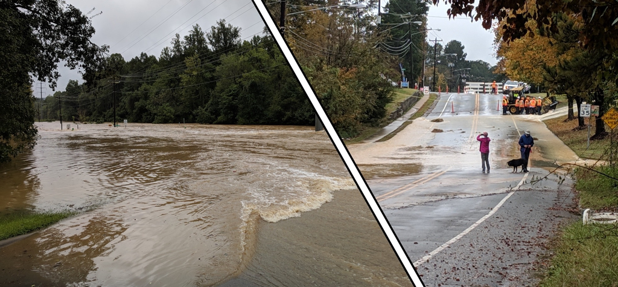

Let’s think about water in the United States for a moment. Where are some areas that you might think have water access issues? How about some areas that might have flooding issues? …Contamination issues?

The west coast of the United States (especially California) is often in the news for water issues. Not only does California use a lot of water for a variety of purposes, but it also recieves relatively less water than much of the rest of the country which can cause water stress. The drought monitor map below shows an all too common trend these days of drought conditions in the west. Further, the abundance of people living in California, along with the large agricultural sector means that water is used at a much higher rate than it is replenished.

[figure not shown]

As Geographers, we’re interested in spatial relationships. Why are things one way over here and another way over there? Why is something similar in two cities thousands of miles apart? what drives these relationships and what can we do to explain them? Can we establish relationships that will allow us to predict events in the future? By establishing these relationships, might we be able to help people avoid the devastating impacts of a hurricane? or gain consistent access to clean drinking water? These are only a few of the infinite number of questions relating to water a geographer might be interested in.

One of the ways we address issues and attempt to answer some of these questions in Geography is by using spatial analysis or geocomputation. Quite simply, this means using data to establish relationships accross space. That space could refer to a building, towns in a state, or the entire world, really anything. Furthermore, spatial analysis can be very simple or very complex. Let’s look at a very simple, but very powerful spatial analysis to get everyone thinking about what spatial analysis is. For this, we will look at water stress accross the United States and try to determine if there are areas aorund the country that are using water at unsustainable levels. The United States Geological Survey (USGS) publishes [water use estimates](https://water.usgs.gov/watuse/data/) every 5-10 years for the entire United States. These are not exact numbers but they offer an accurate estimate of water use at the county level.

There are a number of software packages that geographers make use of to create and analyze spatial data. Some of the more common ones that are used are ArcMap and QGIS which are ‘GUIs’. GUI stands for Graphical User Interface and basically just means that you can use a mouse and actually point and click and drag etc… For example, when you are using google maps on your phone, and you are able to flick your finger to move the map, that is a graphical user interface (GUI). The alternative is called a command line interface, which basically means typing code into a program. The program executes the code to produce results. A common command-line program used for spatial analysis is [R](https://www.r-project.org/). R was originally created as a statistical programming software, and that is still what it is, but over the years it has grown and expanded into a lot more. Personally, I use R because I believe it produces more followable and reproducible research. What I mean by that is when you write code into a program and you save that code, you can always go back and look and see exactly what was done and how the computer went about doing it. In a GUI like ArcMap or QGIS, there is less of a ‘paper-trail’ and it is harder to retrace your steps if you aren’t constantly taking notes on your process. Still, there are many benefits to using GUI based GIS software packages. For example, these softwares have a lot of tools to use with spatial data that are not yet available in programs like R. They are specifically designed to be used for spatial data and thus have a more specific focus. During this lecture I am going to show some code for the purpose of getting you used to looking at it. Don’t feel intimidated if you have no idea what your looking at, thats normal, but I think it’s valuable to see the inner-workings of a spatial analysis in addition to looking at the final product.

First, we load the water use data and we link it to a shapefile of U.S. Counties. This will allow us to create a map of water use, by county, for the year 2015. In most coding languages, a # symbol appears before text that is not code. People who write the code often (and always should) use this type of text to explain what the code below it is actually doing. So if you read through some thoughtfully authored code, there should be enough annotations to explain what is going on. All of the code presented here includes annotations to try and help you understand what is happening without you needing to understand how to exactly read the code itself.

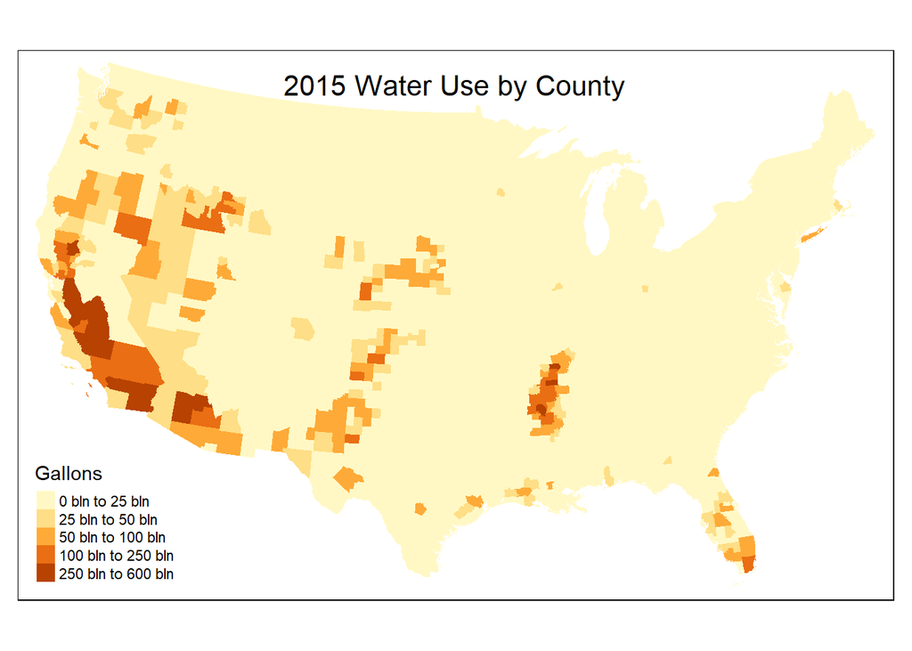

```r
# Import the water use data from USGS and filter the data so we only have what is relevant
WaterUse <- read.csv("D:/OneDrive/OneDrive - University of North Carolina at Chapel Hill/Documents/Fall 2018/geog_702/WaterUse.csv", skip = 1) %>%
  dplyr::select("COUNTY","FIPS","TO.WGWFr")
colnames(WaterUse) <- c("COUNTY","FIPS","MGPD")

WaterUse$totGal <- WaterUse$MGPD * 365 * 1000000

# Import precipitation data from PRISM climate group
ppt <- raster("D:/OneDrive/OneDrive - University of North Carolina at Chapel Hill/Documents/Fall 2018/geog_702/PRISM_ppt_stable_4kmM3_2015_bil.bil")

# Import a county shapefile to use for visualization
Counties <- readOGR("D:/OneDrive/OneDrive - University of North Carolina at Chapel Hill/Documents/Fall 2018/geog_702/data/US_county_2015.shp")
Counties$FIPS <- paste0(Counties$STATEFP,Counties$COUNTYFP)
Counties$FIPS <- as.numeric(Counties$FIPS)

# Add the Water Use data to the counties so we can visualize it
CountiesWU <- merge(Counties,WaterUse)

# Make a visualization
tm_shape(CountiesWU)+
  tm_fill(title = "Gallons", col = "totGal", breaks = c(0,25000000000,50000000000,100000000000,250000000000,600000000000))+
  tm_layout("2015 Water Use by County",
            legend.position = c("left","bottom"),
            title.position = c("center","top"))
```

[figure not shown]

The map we created is on top and let’s take another look at the U.S. drought monitor. Can anyone spot anything troubling about comparing these two maps?

Yes, there appears to be a relationship between places that use the most water and places that are experiencing drought. Congratuulations, you all just performed a visual spatial analysis. Often, just throwing data onto a map and comparing it with other data may give you ideas for potential relationships to explore. but once we do this, we need to dive deeper and see what’s behind these supposed relationships. It’s important to be thoughtful about the way we conduct analyses and the way in which we frame our research. Much of this is nuanced and will come with time and experience, but for now my advice is to constantly ask yourself why you are doing the things you are doing and if there are better ways you could be doing them.

So here we have looked at drought conditions in the U.S. and we have created a map of water use accropss the United States. If we are interested in understanding the relationships between supply and demand of water, what should we look at next? I’ll give you a hint; we have already established demand by looking at water-use, so where is the supply?

Right, so the supply is precipitation. As I mentioned before, we already have some precipitation data for the U.S. for the yaer 2015, so let’s take a look at that. The data for precipitation usually comes in milimeters (mm) so we’ll divide this by 25.4 to convert to inches.

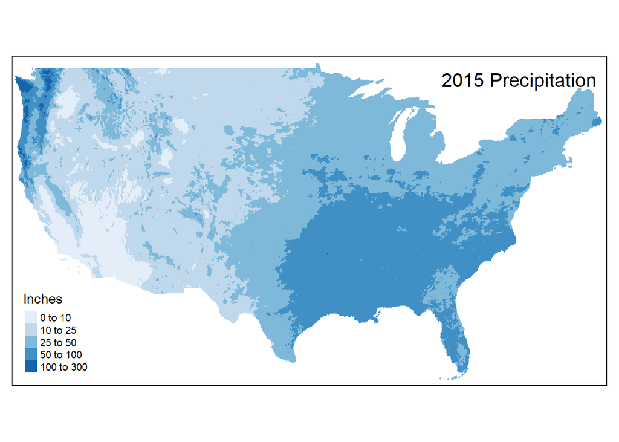

```r
# COnvert to inches fromm milimeters
pptin <- ppt/25.4

# Visualize Precipitation
pptMap <- tm_shape(pptin)+
  tm_raster(palette = "Blues", legend.show = TRUE, title = "Inches", breaks = c(0,10,25,50,100,300))+
  tm_layout("2015 Precipitation",
            legend.position = c("left","bottom"),
            title.position = c("right","top"))
pptMap
```

Here we have precipitation for the year 2015. What ideas do you have on the relationship between rain, drought, and water use in the U.S.? Well obviously there seems to be a strong relationship between drought and precipitation as we would expect. However the relationship is not perfect. For example, remember that this drought map is of recent conditions whereas our water use and precipitation are for the year 2015. Still the trends are similar and informative. Also consider that where water is withdrawn is not necesarrily where it fell as rain. water has the ability to travel hundreds of miles before being withdrawn. You might take some water from the Mississippi river in Louisianna that fellas rain in Iowa for example. Still, it is a usefule exercise to consider who receives the water initially and who is using the most of it.

Let’s dive a little deeper now and calculate the average amount of rain that each county in the U.S. recieved in 2015 and compare that to the amount of water they used in 2015.

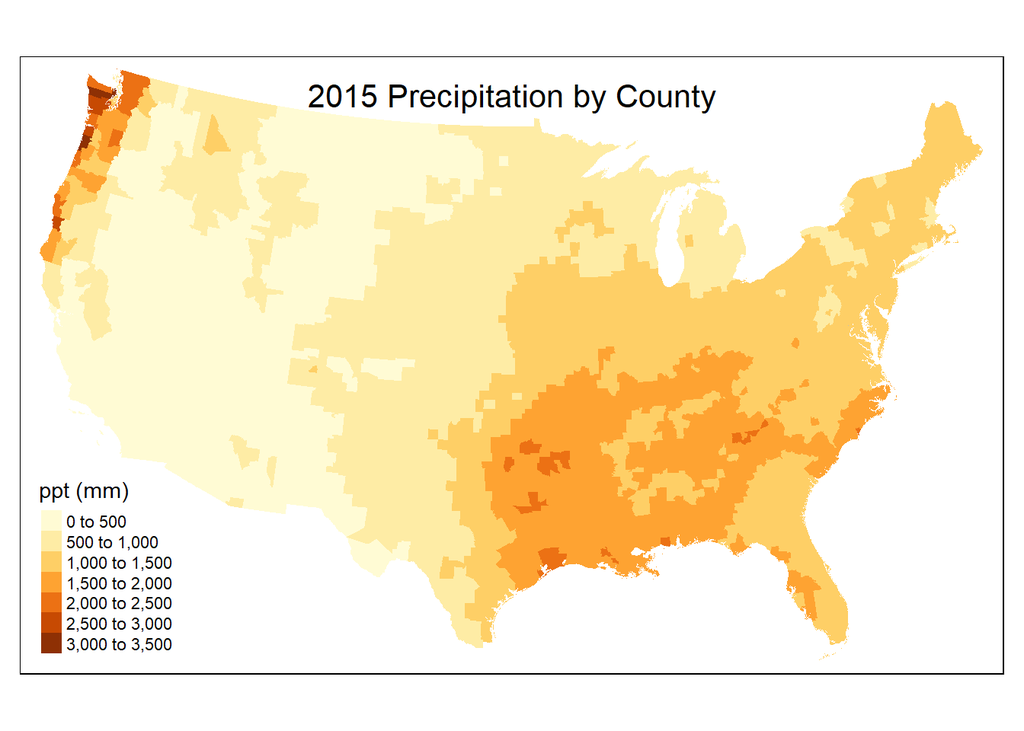

```r
pptCounty <- read.csv("D:/OneDrive/OneDrive - University of North Carolina at Chapel Hill/Documents/Fall 2018/geog_702/data/pptCounty.csv")


CountiesPpt <- merge(CountiesWU,pptCounty, by = "GISJOIN")

tm_shape(CountiesPpt)+
  tm_fill(title = "ppt (mm)", col = "MEAN", showNA = FALSE)+
  tm_layout("2015 Precipitation by County",
            legend.position = c("left","bottom"),
            title.position = c("center","top"))
```

```r
head(CountiesPpt)%>%
  dplyr::select(GISJOIN, ALAND, AWATER, totGal, MEAN)
```

```
##    GISJOIN      ALAND     AWATER      totGal     MEAN
## 1 G0100010 1539589643   25769317  3901850000 1458.691
## 2 G0100030 4117584013 1133129224 26783700000 1736.730
## 3 G0100050 2291820706   50864677  2211900000 1671.105
## 4 G0100070 1612481559    9287974  2069550000 1473.224
## 5 G0100090 1670041875   15077458  1693600000 1576.571
## 6 G0100110 1613059135    6055023  1153400000 1571.852
```

So in this case we have columns already that tell us the area of land and area of water for every county. The units here are square meters. So let’s figure out the total area of the counties then figure out the total volume of water that fell within each county during 2015.

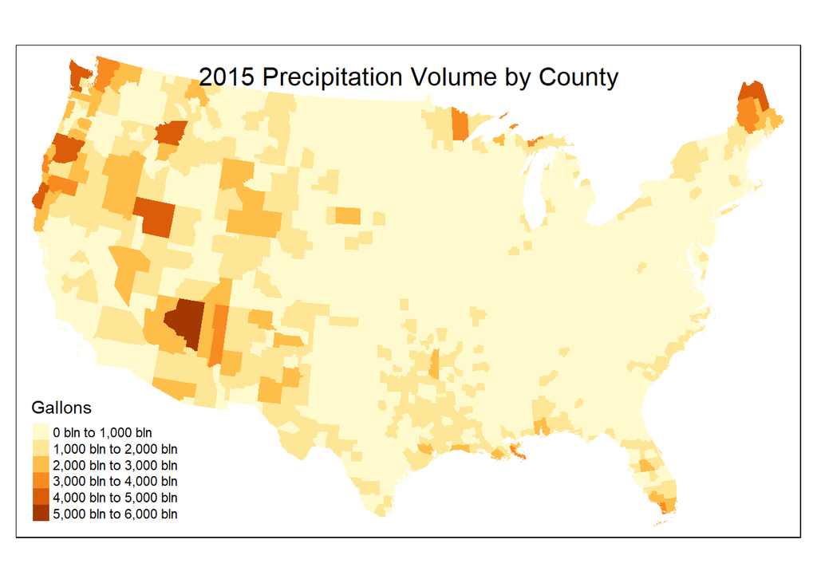

```r
# Add land area and water area together to make total area
CountiesPpt$AreaTot <- CountiesPpt$ALAND+CountiesPpt$AWATER

# Calculate volume of precipitation in cubic meters
CountiesPpt$pptVol3M <- CountiesPpt$AreaTot * (CountiesPpt$MEAN / 1000)

# Convert cubic meters to gallons
CountiesPpt$pptVolGal <- CountiesPpt$pptVol3M * 264.172

# Visualize it!
tm_shape(CountiesPpt)+
  tm_fill(title = "Gallons", col = "pptVolGal", showNA = FALSE)+
  tm_layout("2015 Precipitation Volume by County",
            legend.position = c("left","bottom"),
            title.position = c("center","top"))
```

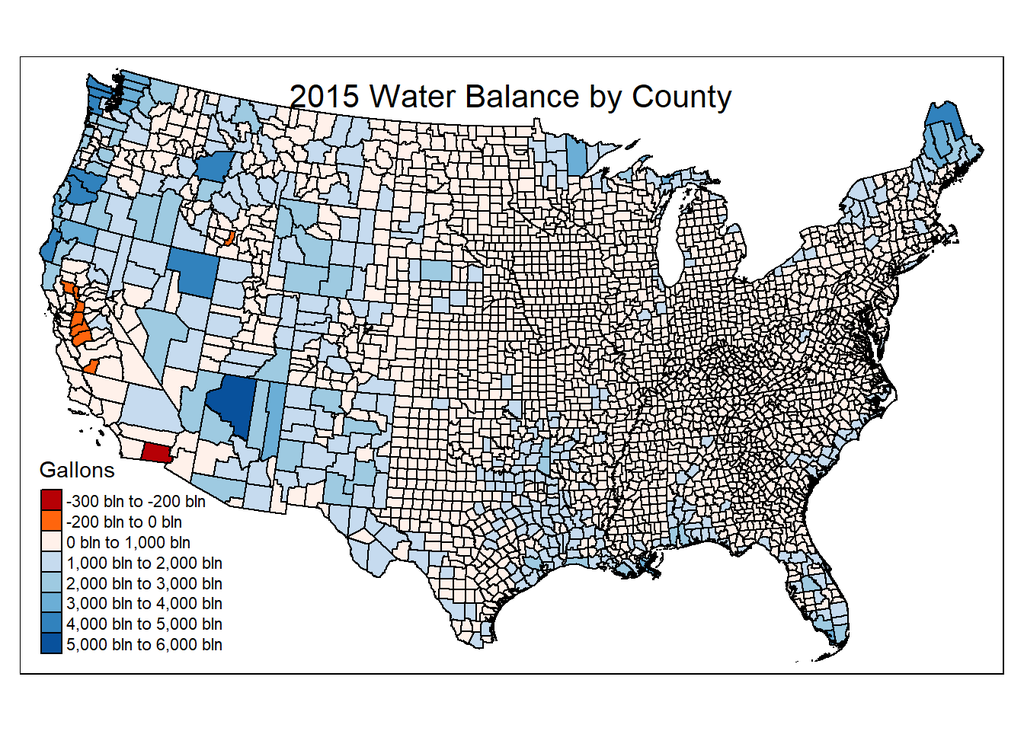

```r
CountiesPpt$WatBal <- CountiesPpt$pptVolGal - (CountiesPpt$totGal)

palette <- c('#B60005','#FF650D','#FFF1EA','#c6dbef','#9ecae1','#6baed6','#3182bd','#08519c')
breaks <- c(-300000000000,-200000000000,0,1000000000000,2000000000000,3000000000000,4000000000000,5000000000000,6000000000000)

tm_shape(CountiesPpt)+
  tm_fill(title = "Gallons", col = "WatBal", breaks = breaks, palette = palette, showNA = FALSE)+
  tm_borders( col = "black")+
  tm_layout("2015 Water Balance by County",
            legend.position = c("left","bottom"),
            title.position = c("center","top"))
```

Our spatial analysis is now complete, the map here shows water balance which is the the amount of water recieved (rain) minus the amount of water used (withdrawn) by county for 2015. The units here are gallons of water. As you can see, the legend shows increments of 1,000 bln gallons (1,000 * 1 billion gallons), or simply: 1 trillion gallons. Take a look at California, most of California’s central valley used between 0 and 200 billion gallons more water than they received. In one county, more than 200 billion gallons of water was lost to usage. Lets take a few moments to discuss some of the things present in this map. By the way, if you’re looking for a point of reference, Hurricane Florence (Considered the second ‘wettest’ storm in the last 70 years behind Hurricane Harvey) [dropped roughly 10 trillion gallons](https://weather.com/storms/hurricane/news/2018-09-19-hurricane-florence-harvey-north-carolina/) of water on the Carolinas (Harvey dropped roughly 33 trillion gallons). These storms dropped more rain in a few days than many areas see in an entire year!

First, one might think that counties with large cities would use more water than they receive due to the huge population size. What could be some reasons why this isn’t true?

The big reason is that domestic water use just simply does not account for much of the water we use. Domestic water use is what we refer to as normal everyday use such as drinking, running the dishwasher, cooking, etc… Basically the water you use at home.

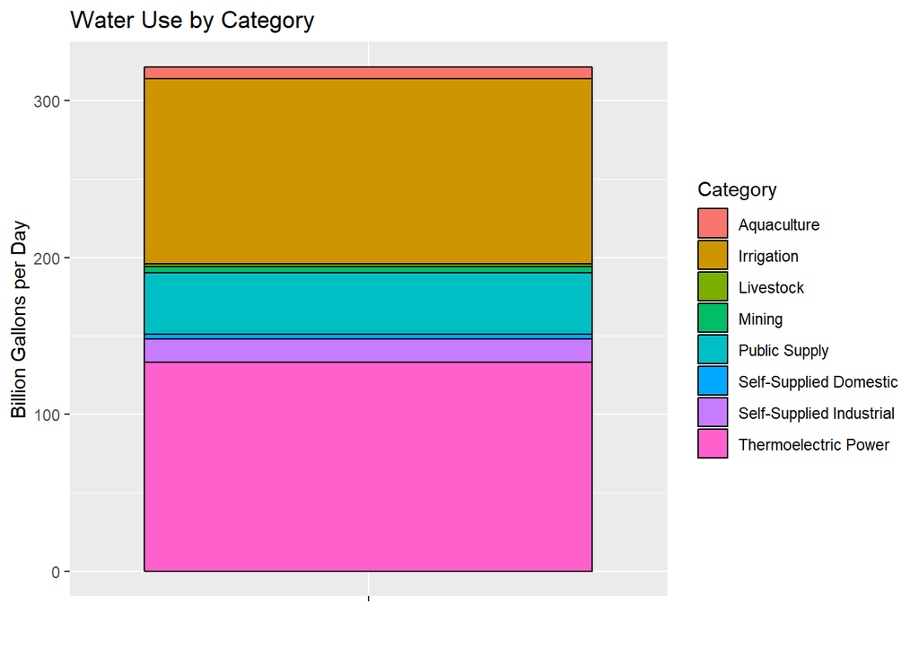

Here, we can look at the amount of water use by category according to that USGS data. Look what a small dent in the overall total self-supplied domestic use makes. Consider that about 16% of all people in the United States self supply domestic water (that basically means they have a private well). Are you surprised by the amount of water used in any of these categories? Check out livestock, you can’t even really see it, it’s so small. What about thermoelectric power? what even is that? what does that mean? Well it turns out it has nothing to do with hydro-electric generated power (water flowing through dams used to kcreate electricity). A lot of our power is generated from sources like coal. However, the way that the electricity is actually created is by using coal to heat up water, convert it to steam and drive steam-powered generators. Take a look at this graphic to see the process of power generation at the Scherer power plant in Georgia. What is the water being used to accomplish? Think about how much electricity the United States must use in a day… is it surprising that it requires all this water to generate it?

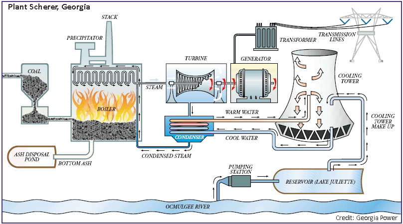

To learn more about thermoelectric power and how water is used for it’s genration check out [this USGS page](https://water.usgs.gov/edu/wupt.html).

So what’s the deal with California? why are they using all this water that they don’t have? How are they using more water than they recieve? Is that even possible? The answer is yes of course it is possible. Groundwater, which is water stored within the cracks and spaces between soil particles and rocks inside the ground builds up over years in years. In fact, some groundwater can be millions of years old. Scientists know this because of isotope analysis methods that allow them to tell how long ago the water fell as rain. The problem is that as our population grows and we use more and more water (especially in parts of the United States) we deplete our groundwater faster than it can be replenished and it turns out that lack of water is not the only consequence. Water actualy makes up a large portion of the earths crust. When we take water out, the earth can actually compress and become smaller. Check out this photo of an area in the San Joaquin Valley in California (One of the ares we already determined has negative water use). This photo shows how far the actual ground has dropped through the decades because of over-withdrawel of groundwater. Obiously this is not just a problem that has popped up in the last few years… it’s been happening for almost a century.

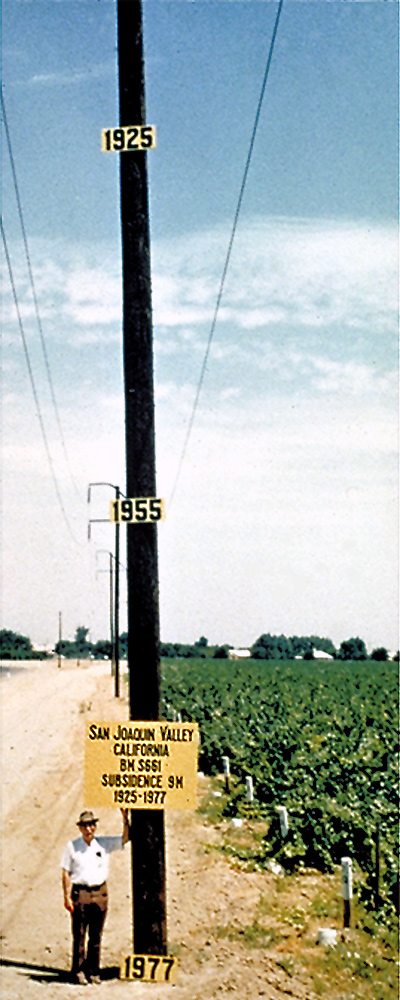

We’ve talked a lot so far about water access and the balance of water (supply vs. demand). It is important to consider however that this is just one small part of a geographers potential work as it relates to water. Geographers consider all sorts of issues. For example, watershed hydrology is a dominant field where researchers try to figure out how nutrients flow through a watershed system. A quick example of this is fertilizer used by the agriculture industry. Fertilizers are rich in nitrate and once appliued to fields, they inevitably run off into the ground, then into streams and rivers. The Mississippi river is one of the largest river systems in the world, and it happens to run straight thorugh the agricultural heartland of the United States. The result of this is that so much nitrate build up in the river by the time it makes it to the gulf of Mexico near New Orleans that it creates a ‘dead zone’ where nothing can grow. You can actually see this from space. In 2017, this [dead zone](https://oceantoday.noaa.gov/happnowdeadzone/) was the size of New Jersey. What happens is that all of these nutrients eat up all of the available oxygen and create an environment where plants and animals cannot survive. Fish and shrimp leave and everything that cannot leave dies. Using a wide variety of tools and modelling programs, hydrology oriented geographers use data to try and determine relationships accross space which contribute to events like this. By understanding where these fertilizers come from and how they move accross landscapes, we are able to predict the impacts downstream and limit their impacts in the future.

Another application of geography that is highly relevant is the impact of hurricanes. We use spatial anlysis to determine the areas that are most likely to flood and be impacted by heavy rainfall and storm surge. When you watch the news and they show a map of predicted inundation or flooding… that’s a geographer doing that analysis. Geographers try to establish how water will impact a community.. If contamination is going to happen, who will it affect? A geographer may be searching for that answer. To conclude this lecture, I would hope that you leave with your mind running wild with the possibilities that geography applied to water issues reveals. There are so many things you can seek out to describe and so many ways you can use to describe them… leading to an infinite number of ways you can actually benefit the lives of other people around the world. Water is essential to life and geographers have the ability to harness the power of critical thought combined with computation to pave the way for a better future for people all over the world.